# Project_4_Bank_Churner_Full_code

#### **Loss function and Recall**

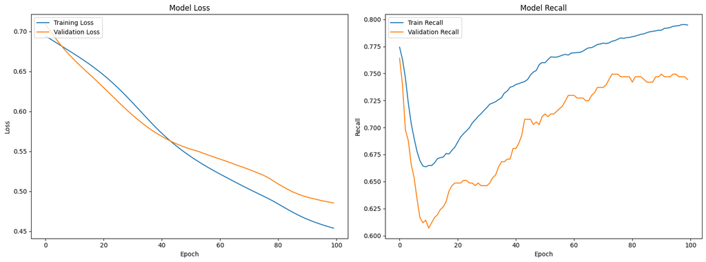

```python
# Create a figure with two subplots side by side
fig, axs = plt.subplots(1, 2, figsize=(16, 6))  # 1 row, 2 columns

# Plot Train Loss vs Validation Loss
axs[0].plot(history_3.history['loss'], label='Training Loss')
axs[0].plot(history_3.history['val_loss'], label='Validation Loss')
axs[0].set_title('Model Loss')
axs[0].set_ylabel('Loss')
axs[0].set_xlabel('Epoch')
axs[0].legend(loc='upper left')

# Plot Train Recall vs Validation Recall
axs[1].plot(history_3.history['Recall'], label='Train Recall')
axs[1].plot(history_3.history['val_Recall'], label='Validation Recall')
axs[1].set_title('Model Recall')
axs[1].set_ylabel('Recall')
axs[1].set_xlabel('Epoch')
axs[1].legend(loc='upper left')

# Adjust layout to avoid overlap
plt.tight_layout()

# Show the plots
plt.show()
```

- After applying SMOTE the model performence is significantly improved.
- Both training and validation loss curves have significantly decreased compared to the previous models. The narrow gap between the training and validation loss curves shows that the issue of overfitting is reduced but still exists.
- The recall for both training and validation sets has increased substantially, indicating better performance in identifying positive cases. While there's still a gap between training and validation recall, it's notably smaller than in the previous models, suggesting improved generalization.

```python
y_train_pred = model_3.predict(X_train_smote)
#Predicting the results using 0.5 as the threshold
y_train_pred = (y_train_pred > 0.5)
y_train_pred
```

```
299/299 ━━━━━━━━━━━━━━━━━━━━ 3s 9ms/step
```

```
array([[False],
       [ True],
       [ True],
       ...,
       [ True],
       [False],
       [ True]])
```

```python
y_val_pred = model_3.predict(X_val)
#Predicting the results using 0.5 as the threshold
y_val_pred = (y_val_pred > 0.5)
y_val_pred
```

```
63/63 ━━━━━━━━━━━━━━━━━━━━ 1s 10ms/step
```

```
array([[False],
       [False],
       [ True],
       ...,
       [False],
       [False],
       [ True]])
```

```python
# Calculate recall for training and validation sets
train_recall = recall_score(y_train_smote, y_train_pred)
valid_recall = recall_score(y_val, y_val_pred)

# Calculate the difference between training and validation recall
recall_difference = train_recall - valid_recall
```

```python
model_name = "NN with SMOTE & SGD"

# Append the metrics to the DataFrame
metrics_df.loc[model_name] = {
    "train_recall": train_recall,
    "valid_recall": valid_recall,
    "recall_difference": recall_difference
}
```

**Classification report**

```python
# Generate and combine classification reports for training and validation datasets
cr_df = pd.concat([
    pd.DataFrame(classification_report(y_train_smote, y_train_pred, output_dict=True)).transpose().assign(datasets='Training'),
    pd.DataFrame(classification_report(y_val, y_val_pred, output_dict=True)).transpose().assign(datasets='Validation')
]).reset_index().set_index('datasets').rename(columns={'index': 'metrices'})

# Display the combined table
cr_df
```

| datasets | metrices | precision | recall | f1-score | support |
| --- | --- | --- | --- | --- | --- |
| Training | 0 | 0.793877 | 0.770777 | 0.782156 | 4777.000000 |
| Training | 1 | 0.777258 | 0.799874 | 0.788404 | 4777.000000 |
| Training | accuracy | 0.785326 | 0.785326 | 0.785326 | 0.785326 |
| Training | macro avg | 0.785567 | 0.785326 | 0.785280 | 9554.000000 |
| Training | weighted avg | 0.785567 | 0.785326 | 0.785280 | 9554.000000 |
| Validation | 0 | 0.921152 | 0.762712 | 0.834478 | 1593.000000 |
| Validation | 1 | 0.444934 | 0.744472 | 0.556985 | 407.000000 |
| Validation | accuracy | 0.759000 | 0.759000 | 0.759000 | 0.759000 |
| Validation | macro avg | 0.683043 | 0.753592 | 0.695732 | 2000.000000 |
| Validation | weighted avg | 0.824242 | 0.759000 | 0.778008 | 2000.000000 |

**Confusion matrix**

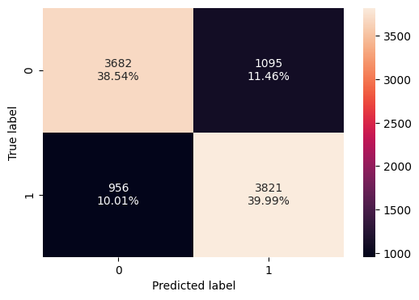

```python
#Calculating the confusion matrix
make_confusion_matrix(y_train_smote, y_train_pred)
```

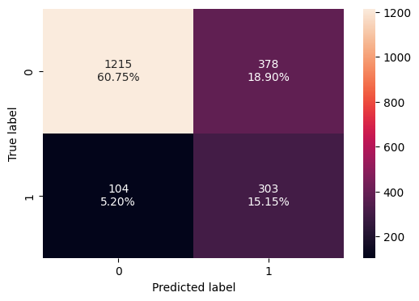

```python
#Calculating the confusion matrix

make_confusion_matrix(y_val, y_val_pred) ## Complete the code to check the model's performance on the validation set
```

### Neural Network with Balanced Data (by applying SMOTE) and Adam Optimizer

Let's build a model with the balanced dataset

```python
backend.clear_session()
#Fixing the seed for random number generators so that we can ensure we receive the same output everytime
np.random.seed(2)
random.seed(2)
tf.random.set_seed(2)
```

```python
# Initializing the model
model_4 = Sequential()

# Adding the input layer with 64 neurons and relu activation function
model_4.add(Dense(64, activation='relu', input_dim=X_train_smote.shape[1]))

# Adding a hidden layer with 32 neurons and relu activation function
model_4.add(Dense(32, activation='relu'))

# Adding another hidden layer with 16 neurons and relu activation function
model_4.add(Dense(16, activation='relu'))

# Adding the output layer with 1 neuron and sigmoid activation function (for binary classification)
model_4.add(Dense(1, activation='sigmoid'))
```

```python
# Compiling the model with Adam optimizer and binary cross entropy loss function with recall as metric
optimizer = Adam(learning_rate=0.001)
metric = 'Recall'
model_4.compile(loss='binary_crossentropy', optimizer=optimizer, metrics=[metric])
```

```python
# Displaying the summary of the model
model_4.summary()
```

```
Model: "sequential"
```

```
┏━━━━━━━━━━━━━━━━━━━━━━━━━━━━━━━━━━━━━━┳━━━━━━━━━━━━━━━━━━━━━━━━━━━━━┳━━━━━━━━━━━━━━━━━┓
┃ Layer (type)                         ┃ Output Shape                ┃         Param # ┃
┡━━━━━━━━━━━━━━━━━━━━━━━━━━━━━━━━━━━━━━╇━━━━━━━━━━━━━━━━━━━━━━━━━━━━━╇━━━━━━━━━━━━━━━━━┩
│ dense (Dense)                        │ (None, 64)                  │             768 │
├──────────────────────────────────────┼─────────────────────────────┼─────────────────┤
│ dense_1 (Dense)                      │ (None, 32)                  │           2,080 │
├──────────────────────────────────────┼─────────────────────────────┼─────────────────┤
│ dense_2 (Dense)                      │ (None, 16)                  │             528 │
├──────────────────────────────────────┼─────────────────────────────┼─────────────────┤
│ dense_3 (Dense)                      │ (None, 1)                   │              17 │
└──────────────────────────────────────┴─────────────────────────────┴─────────────────┘
```

```
 Total params: 3,393 (13.25 KB)
```

```
 Trainable params: 3,393 (13.25 KB)
```

```
 Non-trainable params: 0 (0.00 B)
```

```python
# Fitting the ANN
history_4 = model_4.fit(
    X_train_smote, y_train_smote,
    batch_size=32,  # Specify the batch size
    epochs=100,  # Specify the number of epochs
    verbose=1,
    validation_data=(X_val, y_val)
)
```

```
299/299 ━━━━━━━━━━━━━━━━━━━━ 27s 90ms/step - Recall: 0.6568 - loss: 0.5790 - val_Recall: 0.8059 - val_loss: 0.5341
299/299 ━━━━━━━━━━━━━━━━━━━━ 28s 92ms/step - Recall: 0.7864 - loss: 0.4382 - val_Recall: 0.7862 - val_loss: 0.5173
299/299 ━━━━━━━━━━━━━━━━━━━━ 42s 140ms/step - Recall: 0.7926 - loss: 0.4192 - val_Recall: 0.7789 - val_loss: 0.5185
299/299 ━━━━━━━━━━━━━━━━━━━━ 69s 95ms/step - Recall: 0.8031 - loss: 0.4091 - val_Recall: 0.7715 - val_loss: 0.5138
299/299 ━━━━━━━━━━━━━━━━━━━━ 42s 100ms/step - Recall: 0.8077 - loss: 0.4009 - val_Recall: 0.7518 - val_loss: 0.5117
299/299 ━━━━━━━━━━━━━━━━━━━━ 32s 106ms/step - Recall: 0.8099 - loss: 0.3944 - val_Recall: 0.7568 - val_loss: 0.5110
299/299 ━━━━━━━━━━━━━━━━━━━━ 37s 94ms/step - Recall: 0.8131 - loss: 0.3881 - val_Recall: 0.7445 - val_loss: 0.5068
299/299 ━━━━━━━━━━━━━━━━━━━━ 28s 95ms/step - Recall: 0.8175 - loss: 0.3821 - val_Recall: 0.7371 - val_loss: 0.5054
299/299 ━━━━━━━━━━━━━━━━━━━━ 40s 93ms/step - Recall: 0.8233 - loss: 0.3766 - val_Recall: 0.7322 - val_loss: 0.5037
299/299 ━━━━━━━━━━━━━━━━━━━━ 26s 88ms/step - Recall: 0.8243 - loss: 0.3712 - val_Recall: 0.7322 - val_loss: 0.5044
299/299 ━━━━━━━━━━━━━━━━━━━━ 41s 87ms/step - Recall: 0.8241 - loss: 0.3664 - val_Recall: 0.7224 - val_loss: 0.5064
299/299 ━━━━━━━━━━━━━━━━━━━━ 28s 94ms/step - Recall: 0.8303 - loss: 0.3613 - val_Recall: 0.7150 - val_loss: 0.5060
299/299 ━━━━━━━━━━━━━━━━━━━━ 28s 94ms/step - Recall: 0.8330 - loss: 0.3563 - val_Recall: 0.7076 - val_loss: 0.5008
299/299 ━━━━━━━━━━━━━━━━━━━━ 40s 91ms/step - Recall: 0.8342 - loss: 0.3516 - val_Recall: 0.7027 - val_loss: 0.5035
299/299 ━━━━━━━━━━━━━━━━━━━━ 27s 90ms/step - Recall: 0.8418 - loss: 0.3474 - val_Recall: 0.7076 - val_loss: 0.5070
299/299 ━━━━━━━━━━━━━━━━━━━━ 40s 86ms/step - Recall: 0.8460 - loss: 0.3429 - val_Recall: 0.7002 - val_loss: 0.5097
299/299 ━━━━━━━━━━━━━━━━━━━━ 41s 88ms/step - Recall: 0.8476 - loss: 0.3387 - val_Recall: 0.6978 - val_loss: 0.5088
299/299 ━━━━━━━━━━━━━━━━━━━━ 41s 89ms/step - Recall: 0.8534 - loss: 0.3346 - val_Recall: 0.6978 - val_loss: 0.5090
299/299 ━━━━━━━━━━━━━━━━━━━━ 42s 93ms/step - Recall: 0.8546 - loss: 0.3308 - val_Recall: 0.6953 - val_loss: 0.5107
299/299 ━━━━━━━━━━━━━━━━━━━━ 27s 89ms/step - Recall: 0.8564 - loss: 0.3270 - val_Recall: 0.6929 - val_loss: 0.5131
299/299 ━━━━━━━━━━━━━━━━━━━━ 27s 89ms/step - Recall: 0.8600 - loss: 0.3234 - val_Recall: 0.6904 - val_loss: 0.5136
299/299 ━━━━━━━━━━━━━━━━━━━━ 27s 90ms/step - Recall: 0.8607 - loss: 0.3195 - val_Recall: 0.6855 - val_loss: 0.5136
299/299 ━━━━━━━━━━━━━━━━━━━━ 27s 88ms/step - Recall: 0.8650 - loss: 0.3150 - val_Recall: 0.6781 - val_loss: 0.5131
299/299 ━━━━━━━━━━━━━━━━━━━━ 26s 87ms/step - Recall: 0.8689 - loss: 0.3114 - val_Recall: 0.6806 - val_loss: 0.5122
299/299 ━━━━━━━━━━━━━━━━━━━━ 42s 90ms/step - Recall: 0.8712 - loss: 0.3063 - val_Recall: 0.6757 - val_loss: 0.5118
299/299 ━━━━━━━━━━━━━━━━━━━━ 28s 94ms/step - Recall: 0.8759 - loss: 0.3022 - val_Recall: 0.6732 - val_loss: 0.5160
299/299 ━━━━━━━━━━━━━━━━━━━━ 28s 93ms/step - Recall: 0.8794 - loss: 0.2982 - val_Recall: 0.6658 - val_loss: 0.5176
299/299 ━━━━━━━━━━━━━━━━━━━━ 39s 88ms/step - Recall: 0.8781 - loss: 0.2940 - val_Recall: 0.6683 - val_loss: 0.5181
299/299 ━━━━━━━━━━━━━━━━━━━━ 37s 125ms/step - Recall: 0.8808 - loss: 0.2905 - val_Recall: 0.6683 - val_loss: 0.5205
299/299 ━━━━━━━━━━━━━━━━━━━━ 31s 102ms/step - Recall: 0.8841 - loss: 0.2868 - val_Recall: 0.6634 - val_loss: 0.5239
299/299 ━━━━━━━━━━━━━━━━━━━━ 28s 92ms/step - Recall: 0.8844 - loss: 0.2840 - val_Recall: 0.6609 - val_loss: 0.5271
299/299 ━━━━━━━━━━━━━━━━━━━━ 27s 91ms/step - Recall: 0.8877 - loss: 0.2810 - val_Recall: 0.6609 - val_loss: 0.5279
299/299 ━━━━━━━━━━━━━━━━━━━━ 27s 89ms/step - Recall: 0.8900 - loss: 0.2774 - val_Recall: 0.6560 - val_loss: 0.5300
299/299 ━━━━━━━━━━━━━━━━━━━━ 42s 92ms/step - Recall: 0.8899 - loss: 0.2740 - val_Recall: 0.6585 - val_loss: 0.5323
299/299 ━━━━━━━━━━━━━━━━━━━━ 42s 95ms/step - Recall: 0.8901 - loss: 0.2714 - val_Recall: 0.6536 - val_loss: 0.5366
299/299 ━━━━━━━━━━━━━━━━━━━━ 39s 90ms/step - Recall: 0.8924 - loss: 0.2686 - val_Recall: 0.6462 - val_loss: 0.5378
299/299 ━━━━━━━━━━━━━━━━━━━━ 41s 90ms/step - Recall: 0.8939 - loss: 0.2656 - val_Recall: 0.6413 - val_loss: 0.5413
299/299 ━━━━━━━━━━━━━━━━━━━━ 41s 89ms/step - Recall: 0.8956 - loss: 0.2628 - val_Recall: 0.6437 - val_loss: 0.5442
299/299 ━━━━━━━━━━━━━━━━━━━━ 26s 87ms/step - Recall: 0.8956 - loss: 0.2604 - val_Recall: 0.6437 - val_loss: 0.5430
299/299 ━━━━━━━━━━━━━━━━━━━━ 28s 95ms/step - Recall: 0.8967 - loss: 0.2570 - val_Recall: 0.6462 - val_loss: 0.5492
```

[output cut: 45 more lines]

```
299/299 ━━━━━━━━━━━━━━━━━━━━ 25s 84ms/step - Recall: 0.9466 - loss: 0.1630 - val_Recall: 0.6192 - val_loss: 0.7277
299/299 ━━━━━━━━━━━━━━━━━━━━ 24s 79ms/step - Recall: 0.9478 - loss: 0.1612 - val_Recall: 0.6216 - val_loss: 0.7309
299/299 ━━━━━━━━━━━━━━━━━━━━ 43s 85ms/step - Recall: 0.9458 - loss: 0.1591 - val_Recall: 0.6265 - val_loss: 0.7421
299/299 ━━━━━━━━━━━━━━━━━━━━ 41s 86ms/step - Recall: 0.9483 - loss: 0.1581 - val_Recall: 0.6167 - val_loss: 0.7478
299/299 ━━━━━━━━━━━━━━━━━━━━ 26s 87ms/step - Recall: 0.9482 - loss: 0.1559 - val_Recall: 0.6192 - val_loss: 0.7524
299/299 ━━━━━━━━━━━━━━━━━━━━ 42s 90ms/step - Recall: 0.9512 - loss: 0.1546 - val_Recall: 0.6143 - val_loss: 0.7565
299/299 ━━━━━━━━━━━━━━━━━━━━ 27s 90ms/step - Recall: 0.9492 - loss: 0.1527 - val_Recall: 0.6093 - val_loss: 0.7591
299/299 ━━━━━━━━━━━━━━━━━━━━ 41s 92ms/step - Recall: 0.9498 - loss: 0.1516 - val_Recall: 0.6069 - val_loss: 0.7645
299/299 ━━━━━━━━━━━━━━━━━━━━ 28s 93ms/step - Recall: 0.9520 - loss: 0.1498 - val_Recall: 0.6069 - val_loss: 0.7722
299/299 ━━━━━━━━━━━━━━━━━━━━ 41s 93ms/step - Recall: 0.9521 - loss: 0.1485 - val_Recall: 0.5995 - val_loss: 0.7718
299/299 ━━━━━━━━━━━━━━━━━━━━ 27s 92ms/step - Recall: 0.9533 - loss: 0.1468 - val_Recall: 0.6020 - val_loss: 0.7784
299/299 ━━━━━━━━━━━━━━━━━━━━ 28s 94ms/step - Recall: 0.9545 - loss: 0.1451 - val_Recall: 0.6044 - val_loss: 0.7859
299/299 ━━━━━━━━━━━━━━━━━━━━ 40s 90ms/step - Recall: 0.9512 - loss: 0.1441 - val_Recall: 0.5946 - val_loss: 0.7873
299/299 ━━━━━━━━━━━━━━━━━━━━ 29s 95ms/step - Recall: 0.9543 - loss: 0.1431 - val_Recall: 0.5921 - val_loss: 0.7969
299/299 ━━━━━━━━━━━━━━━━━━━━ 28s 92ms/step - Recall: 0.9542 - loss: 0.1405 - val_Recall: 0.6020 - val_loss: 0.8042
```

**Loss function**

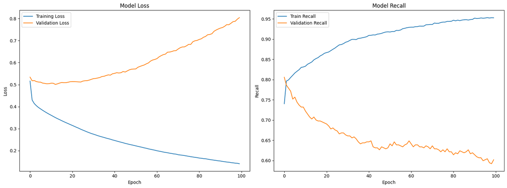

```python
# Create a figure with two subplots side by side
fig, axs = plt.subplots(1, 2, figsize=(16, 6))  # 1 row, 2 columns

# Plot Train Loss vs Validation Loss
axs[0].plot(history_4.history['loss'], label='Training Loss')
axs[0].plot(history_4.history['val_loss'], label='Validation Loss')
axs[0].set_title('Model Loss')
axs[0].set_ylabel('Loss')
axs[0].set_xlabel('Epoch')
axs[0].legend(loc='upper left')

# Plot Train Recall vs Validation Recall
axs[1].plot(history_4.history['Recall'], label='Train Recall')
axs[1].plot(history_4.history['val_Recall'], label='Validation Recall')
axs[1].set_title('Model Recall')
axs[1].set_ylabel('Recall')
axs[1].set_xlabel('Epoch')
axs[1].legend(loc='upper left')

# Adjust layout to avoid overlap
plt.tight_layout()

# Show the plots
plt.show()
```

- The model shows promise in learning the underlying patterns, as evidenced by the decreasing loss and increasing recall during the initial training phase.
- The subsequent divergence between training and validation metrics highlights the need for regularization techniques or hyperparameter tuning to mitigate overfitting and improve generalization performance.

```python
y_train_pred = model_4.predict(X_train_smote)
#Predicting the results using 0.5 as the threshold
y_train_pred = (y_train_pred > 0.5)
y_train_pred
```

```
299/299 ━━━━━━━━━━━━━━━━━━━━ 2s 7ms/step
```

```
array([[False],
       [ True],
       [ True],
       ...,
       [ True],
       [ True],
       [ True]])
```

```python
y_val_pred = model_4.predict(X_val)
#Predicting the results using 0.5 as the threshold
y_val_pred = (y_val_pred > 0.5)
y_val_pred
```

```
63/63 ━━━━━━━━━━━━━━━━━━━━ 0s 6ms/step
```

```
array([[False],
       [False],
       [ True],
       ...,
       [False],
       [False],
       [False]])
```

```python
# Calculate recall for training and validation sets
train_recall = recall_score(y_train_smote, y_train_pred)
valid_recall = recall_score(y_val, y_val_pred)

# Calculate the difference between training and validation recall
recall_difference = train_recall - valid_recall
```

```python
model_name = "NN with SMOTE & Adam"

# Append the metrics to the DataFrame
metrics_df.loc[model_name] = {
    "train_recall": train_recall,
    "valid_recall": valid_recall,
    "recall_difference": recall_difference
}
```

**Classification report**

```python
# Generate and combine classification reports for training and validation datasets
cr_df = pd.concat([
    pd.DataFrame(classification_report(y_train_smote, y_train_pred, output_dict=True)).transpose().assign(datasets='Training'),
    pd.DataFrame(classification_report(y_val, y_val_pred, output_dict=True)).transpose().assign(datasets='Validation')
]).reset_index().set_index('datasets').rename(columns={'index': 'metrices'})

# Display the combined table
cr_df
```

| datasets | metrices | precision | recall | f1-score | support |
| --- | --- | --- | --- | --- | --- |
| Training | 0 | 0.967964 | 0.910823 | 0.938525 | 4777.000000 |
| Training | 1 | 0.915794 | 0.969856 | 0.942050 | 4777.000000 |
| Training | accuracy | 0.940339 | 0.940339 | 0.940339 | 0.940339 |
| Training | macro avg | 0.941879 | 0.940339 | 0.940287 | 9554.000000 |
| Training | weighted avg | 0.941879 | 0.940339 | 0.940287 | 9554.000000 |
| Validation | 0 | 0.891928 | 0.839297 | 0.864812 | 1593.000000 |
| Validation | 1 | 0.489022 | 0.601966 | 0.539648 | 407.000000 |
| Validation | accuracy | 0.791000 | 0.791000 | 0.791000 | 0.791000 |
| Validation | macro avg | 0.690475 | 0.720631 | 0.702230 | 2000.000000 |
| Validation | weighted avg | 0.809937 | 0.791000 | 0.798641 | 2000.000000 |

- The model shows significant performance disparity between the majority and minority classes.
- It is achieving high precision, recall, and F1-score for the majority class on both training and validation sets, the model struggles to accurately predict the minority class. The model shows signs of overfitting as indicated by the gap in performance between training and validation sets, particularly for the minority class.

**Confusion matrix**

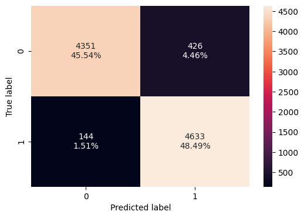

```python
#Calculating the confusion matrix
make_confusion_matrix(y_train_smote, y_train_pred)
```

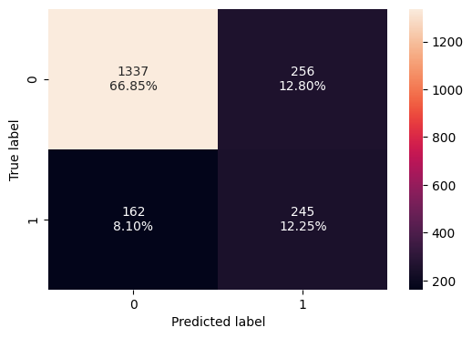

```python
#Calculating the confusion matrix
make_confusion_matrix(y_val,y_val_pred)  ## Complete the code to check the model's performance on the validation set
```

### Neural Network with Balanced Data (by applying SMOTE), Adam Optimizer, and Dropout

```python
backend.clear_session()
#Fixing the seed for random number generators so that we can ensure we receive the same output everytime
np.random.seed(2)
random.seed(2)
tf.random.set_seed(2)
```

```python
# Initializing the neural network
model_5 = Sequential()

# Adding the input layer with 32 neurons and relu as activation function
model_5.add(Dense(32, activation='relu', input_dim=X_train_smote.shape[1]))

# Adding dropout with a ratio of 0.2
model_5.add(Dropout(0.2))

# Adding a hidden layer with 64 neurons and relu as activation function
model_5.add(Dense(64, activation='relu'))

# Adding a hidden layer with 32 neurons and relu as activation function
model_5.add(Dense(32, activation='relu'))

# Adding dropout with a ratio of 0.1
model_5.add(Dropout(0.1))

# Adding a hidden layer with 8 neurons and relu as activation function
model_5.add(Dense(8, activation='relu'))

# Adding the output layer with 1 neuron (for binary classification) and sigmoid activation function
model_5.add(Dense(1, activation='sigmoid'))
```

```python
# Define the Adam optimizer
optimizer = Adam(learning_rate=0.001)

# Compile the model with binary cross entropy as loss function and recall as the metric
metric = 'Recall'
model_5.compile(loss='binary_crossentropy', optimizer=optimizer, metrics=[metric])
```

```python
# Summary of the model
model_5.summary()
```

```
Model: "sequential"
```

```
┏━━━━━━━━━━━━━━━━━━━━━━━━━━━━━━━━━━━━━━┳━━━━━━━━━━━━━━━━━━━━━━━━━━━━━┳━━━━━━━━━━━━━━━━━┓
┃ Layer (type)                         ┃ Output Shape                ┃         Param # ┃
┡━━━━━━━━━━━━━━━━━━━━━━━━━━━━━━━━━━━━━━╇━━━━━━━━━━━━━━━━━━━━━━━━━━━━━╇━━━━━━━━━━━━━━━━━┩
│ dense (Dense)                        │ (None, 32)                  │             384 │
├──────────────────────────────────────┼─────────────────────────────┼─────────────────┤
│ dropout (Dropout)                    │ (None, 32)                  │               0 │
├──────────────────────────────────────┼─────────────────────────────┼─────────────────┤
│ dense_1 (Dense)                      │ (None, 64)                  │           2,112 │
├──────────────────────────────────────┼─────────────────────────────┼─────────────────┤
│ dense_2 (Dense)                      │ (None, 32)                  │           2,080 │
├──────────────────────────────────────┼─────────────────────────────┼─────────────────┤
│ dropout_1 (Dropout)                  │ (None, 32)                  │               0 │
├──────────────────────────────────────┼─────────────────────────────┼─────────────────┤
│ dense_3 (Dense)                      │ (None, 8)                   │             264 │
├──────────────────────────────────────┼─────────────────────────────┼─────────────────┤
│ dense_4 (Dense)                      │ (None, 1)                   │               9 │
└──────────────────────────────────────┴─────────────────────────────┴─────────────────┘
```

```
 Total params: 14,549 (56.84 KB)
```

```
 Trainable params: 4,849 (18.94 KB)
```

```
 Non-trainable params: 0 (0.00 B)
```

```
 Optimizer params: 9,700 (37.89 KB)
```

```python
# Fitting the ANN with batch_size = 32 and 100 epochs
history_5= model_5.fit(
    X_train_smote, y_train_smote,
    batch_size=32,
    epochs=100,
    verbose=1,
    validation_data=(X_val, y_val)
)
```

```
299/299 ━━━━━━━━━━━━━━━━━━━━ 38s 124ms/step - Recall: 0.5674 - loss: 0.6140 - val_Recall: 0.8084 - val_loss: 0.5693
299/299 ━━━━━━━━━━━━━━━━━━━━ 36s 110ms/step - Recall: 0.7546 - loss: 0.4892 - val_Recall: 0.7936 - val_loss: 0.5362
299/299 ━━━━━━━━━━━━━━━━━━━━ 34s 114ms/step - Recall: 0.7614 - loss: 0.4687 - val_Recall: 0.8108 - val_loss: 0.5437
299/299 ━━━━━━━━━━━━━━━━━━━━ 34s 113ms/step - Recall: 0.7793 - loss: 0.4566 - val_Recall: 0.7887 - val_loss: 0.5383
299/299 ━━━━━━━━━━━━━━━━━━━━ 34s 112ms/step - Recall: 0.7718 - loss: 0.4444 - val_Recall: 0.7813 - val_loss: 0.5160
299/299 ━━━━━━━━━━━━━━━━━━━━ 31s 105ms/step - Recall: 0.7824 - loss: 0.4356 - val_Recall: 0.7789 - val_loss: 0.5172
299/299 ━━━━━━━━━━━━━━━━━━━━ 30s 101ms/step - Recall: 0.7904 - loss: 0.4342 - val_Recall: 0.7764 - val_loss: 0.5117
299/299 ━━━━━━━━━━━━━━━━━━━━ 43s 108ms/step - Recall: 0.7893 - loss: 0.4313 - val_Recall: 0.7961 - val_loss: 0.5238
299/299 ━━━━━━━━━━━━━━━━━━━━ 42s 112ms/step - Recall: 0.7953 - loss: 0.4265 - val_Recall: 0.8010 - val_loss: 0.5122
299/299 ━━━━━━━━━━━━━━━━━━━━ 41s 113ms/step - Recall: 0.7972 - loss: 0.4258 - val_Recall: 0.7936 - val_loss: 0.4934
299/299 ━━━━━━━━━━━━━━━━━━━━ 34s 113ms/step - Recall: 0.8082 - loss: 0.4189 - val_Recall: 0.8084 - val_loss: 0.5177
299/299 ━━━━━━━━━━━━━━━━━━━━ 41s 113ms/step - Recall: 0.8055 - loss: 0.4195 - val_Recall: 0.7690 - val_loss: 0.4903
299/299 ━━━━━━━━━━━━━━━━━━━━ 40s 111ms/step - Recall: 0.8026 - loss: 0.4176 - val_Recall: 0.8108 - val_loss: 0.5120
299/299 ━━━━━━━━━━━━━━━━━━━━ 42s 113ms/step - Recall: 0.8123 - loss: 0.4104 - val_Recall: 0.7887 - val_loss: 0.5046
299/299 ━━━━━━━━━━━━━━━━━━━━ 33s 111ms/step - Recall: 0.8089 - loss: 0.4074 - val_Recall: 0.7764 - val_loss: 0.4883
299/299 ━━━━━━━━━━━━━━━━━━━━ 32s 106ms/step - Recall: 0.8152 - loss: 0.4132 - val_Recall: 0.8084 - val_loss: 0.4925
299/299 ━━━━━━━━━━━━━━━━━━━━ 41s 107ms/step - Recall: 0.8194 - loss: 0.4065 - val_Recall: 0.8108 - val_loss: 0.5189
299/299 ━━━━━━━━━━━━━━━━━━━━ 35s 117ms/step - Recall: 0.8236 - loss: 0.4044 - val_Recall: 0.8010 - val_loss: 0.4979
299/299 ━━━━━━━━━━━━━━━━━━━━ 39s 112ms/step - Recall: 0.8231 - loss: 0.3986 - val_Recall: 0.8084 - val_loss: 0.5301
299/299 ━━━━━━━━━━━━━━━━━━━━ 42s 114ms/step - Recall: 0.8172 - loss: 0.4041 - val_Recall: 0.8157 - val_loss: 0.5203
299/299 ━━━━━━━━━━━━━━━━━━━━ 40s 111ms/step - Recall: 0.8270 - loss: 0.3951 - val_Recall: 0.8133 - val_loss: 0.5154
299/299 ━━━━━━━━━━━━━━━━━━━━ 41s 112ms/step - Recall: 0.8252 - loss: 0.4040 - val_Recall: 0.8206 - val_loss: 0.5163
299/299 ━━━━━━━━━━━━━━━━━━━━ 40s 109ms/step - Recall: 0.8300 - loss: 0.3924 - val_Recall: 0.7936 - val_loss: 0.4929
299/299 ━━━━━━━━━━━━━━━━━━━━ 41s 108ms/step - Recall: 0.8282 - loss: 0.3946 - val_Recall: 0.8182 - val_loss: 0.5358
299/299 ━━━━━━━━━━━━━━━━━━━━ 32s 108ms/step - Recall: 0.8323 - loss: 0.3963 - val_Recall: 0.8034 - val_loss: 0.5042
299/299 ━━━━━━━━━━━━━━━━━━━━ 34s 113ms/step - Recall: 0.8247 - loss: 0.3945 - val_Recall: 0.8133 - val_loss: 0.5177
299/299 ━━━━━━━━━━━━━━━━━━━━ 34s 112ms/step - Recall: 0.8293 - loss: 0.3906 - val_Recall: 0.7961 - val_loss: 0.5209
299/299 ━━━━━━━━━━━━━━━━━━━━ 40s 108ms/step - Recall: 0.8354 - loss: 0.3855 - val_Recall: 0.7985 - val_loss: 0.5182
299/299 ━━━━━━━━━━━━━━━━━━━━ 43s 115ms/step - Recall: 0.8381 - loss: 0.3919 - val_Recall: 0.8010 - val_loss: 0.5134
299/299 ━━━━━━━━━━━━━━━━━━━━ 33s 111ms/step - Recall: 0.8370 - loss: 0.3862 - val_Recall: 0.8010 - val_loss: 0.5138
299/299 ━━━━━━━━━━━━━━━━━━━━ 34s 115ms/step - Recall: 0.8362 - loss: 0.3833 - val_Recall: 0.7887 - val_loss: 0.5094
299/299 ━━━━━━━━━━━━━━━━━━━━ 33s 109ms/step - Recall: 0.8297 - loss: 0.3802 - val_Recall: 0.7912 - val_loss: 0.5076
299/299 ━━━━━━━━━━━━━━━━━━━━ 42s 113ms/step - Recall: 0.8400 - loss: 0.3801 - val_Recall: 0.7862 - val_loss: 0.4995
299/299 ━━━━━━━━━━━━━━━━━━━━ 33s 112ms/step - Recall: 0.8413 - loss: 0.3862 - val_Recall: 0.7862 - val_loss: 0.5138
299/299 ━━━━━━━━━━━━━━━━━━━━ 42s 114ms/step - Recall: 0.8395 - loss: 0.3817 - val_Recall: 0.7887 - val_loss: 0.5149
299/299 ━━━━━━━━━━━━━━━━━━━━ 41s 112ms/step - Recall: 0.8525 - loss: 0.3705 - val_Recall: 0.8010 - val_loss: 0.5199
299/299 ━━━━━━━━━━━━━━━━━━━━ 33s 110ms/step - Recall: 0.8401 - loss: 0.3799 - val_Recall: 0.7862 - val_loss: 0.5204
299/299 ━━━━━━━━━━━━━━━━━━━━ 32s 108ms/step - Recall: 0.8434 - loss: 0.3747 - val_Recall: 0.7715 - val_loss: 0.5022
299/299 ━━━━━━━━━━━━━━━━━━━━ 34s 113ms/step - Recall: 0.8433 - loss: 0.3783 - val_Recall: 0.7764 - val_loss: 0.5204
299/299 ━━━━━━━━━━━━━━━━━━━━ 33s 109ms/step - Recall: 0.8415 - loss: 0.3669 - val_Recall: 0.7740 - val_loss: 0.5089
```

[output cut: 45 more lines]

```
299/299 ━━━━━━━━━━━━━━━━━━━━ 41s 110ms/step - Recall: 0.8601 - loss: 0.3390 - val_Recall: 0.7789 - val_loss: 0.5276
299/299 ━━━━━━━━━━━━━━━━━━━━ 41s 109ms/step - Recall: 0.8722 - loss: 0.3300 - val_Recall: 0.7469 - val_loss: 0.5137
299/299 ━━━━━━━━━━━━━━━━━━━━ 40s 106ms/step - Recall: 0.8729 - loss: 0.3332 - val_Recall: 0.7494 - val_loss: 0.5072
299/299 ━━━━━━━━━━━━━━━━━━━━ 41s 108ms/step - Recall: 0.8649 - loss: 0.3457 - val_Recall: 0.7641 - val_loss: 0.5268
299/299 ━━━━━━━━━━━━━━━━━━━━ 34s 113ms/step - Recall: 0.8633 - loss: 0.3401 - val_Recall: 0.7346 - val_loss: 0.5094
299/299 ━━━━━━━━━━━━━━━━━━━━ 34s 114ms/step - Recall: 0.8579 - loss: 0.3370 - val_Recall: 0.7420 - val_loss: 0.5224
299/299 ━━━━━━━━━━━━━━━━━━━━ 41s 114ms/step - Recall: 0.8662 - loss: 0.3390 - val_Recall: 0.7469 - val_loss: 0.5045
299/299 ━━━━━━━━━━━━━━━━━━━━ 41s 115ms/step - Recall: 0.8764 - loss: 0.3299 - val_Recall: 0.7715 - val_loss: 0.5259
299/299 ━━━━━━━━━━━━━━━━━━━━ 40s 112ms/step - Recall: 0.8747 - loss: 0.3323 - val_Recall: 0.7445 - val_loss: 0.5205
299/299 ━━━━━━━━━━━━━━━━━━━━ 42s 115ms/step - Recall: 0.8646 - loss: 0.3299 - val_Recall: 0.7494 - val_loss: 0.5167
299/299 ━━━━━━━━━━━━━━━━━━━━ 41s 114ms/step - Recall: 0.8624 - loss: 0.3273 - val_Recall: 0.7568 - val_loss: 0.5251
299/299 ━━━━━━━━━━━━━━━━━━━━ 39s 109ms/step - Recall: 0.8832 - loss: 0.3250 - val_Recall: 0.7494 - val_loss: 0.5290
299/299 ━━━━━━━━━━━━━━━━━━━━ 35s 116ms/step - Recall: 0.8739 - loss: 0.3337 - val_Recall: 0.7592 - val_loss: 0.5189
299/299 ━━━━━━━━━━━━━━━━━━━━ 33s 110ms/step - Recall: 0.8714 - loss: 0.3302 - val_Recall: 0.7518 - val_loss: 0.5060
299/299 ━━━━━━━━━━━━━━━━━━━━ 33s 111ms/step - Recall: 0.8669 - loss: 0.3283 - val_Recall: 0.7346 - val_loss: 0.5043
```

**Loss function**

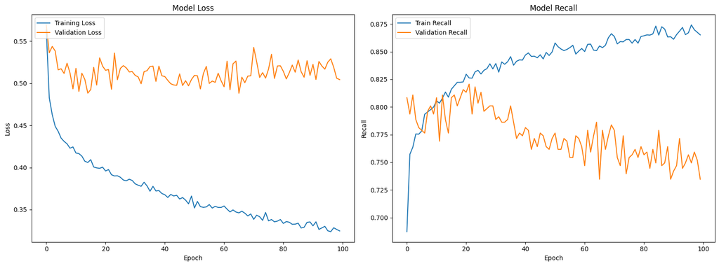

```python
# Create a figure with two subplots side by side
fig, axs = plt.subplots(1, 2, figsize=(16, 6))  # 1 row, 2 columns

# Plot Train Loss vs Validation Loss
axs[0].plot(history_5.history['loss'], label='Training Loss')
axs[0].plot(history_5.history['val_loss'], label='Validation Loss')
axs[0].set_title('Model Loss')
axs[0].set_ylabel('Loss')
axs[0].set_xlabel('Epoch')
axs[0].legend(loc='upper left')

# Plot Train Recall vs Validation Recall
axs[1].plot(history_5.history['Recall'], label='Train Recall')
axs[1].plot(history_5.history['val_Recall'], label='Validation Recall')
axs[1].set_title('Model Recall')
axs[1].set_ylabel('Recall')
axs[1].set_xlabel('Epoch')
axs[1].legend(loc='upper left')

# Adjust layout to avoid overlap
plt.tight_layout()

# Show the plots
plt.show()
```

- The model exhibits signs of overfitting as the gap between training and validation metrics widens over time.

```python
y_train_pred = model_5.predict(X_train_smote)
#Predicting the results using 0.5 as the threshold
y_train_pred = (y_train_pred > 0.5)
y_train_pred
```

```
299/299 ━━━━━━━━━━━━━━━━━━━━ 3s 9ms/step
```

```
array([[ True],
       [ True],
       [False],
       ...,
       [ True],
       [ True],
       [ True]])
```

```python
y_val_pred = model_5.predict(X_val)
#Predicting the results using 0.5 as the threshold
y_val_pred = (y_val_pred > 0.5)
y_val_pred
```

```
63/63 ━━━━━━━━━━━━━━━━━━━━ 1s 8ms/step
```

```
array([[False],
       [False],
       [ True],
       ...,
       [False],
       [False],
       [ True]])
```

```python
# Calculate recall for training and validation sets
train_recall = recall_score(y_train_smote, y_train_pred)
valid_recall = recall_score(y_val, y_val_pred)

# Calculate the difference between training and validation recall
recall_difference = train_recall - valid_recall
```

```python
model_name = "NN with SMOTE, Adam & Dropout"

# Append the metrics to the DataFrame
metrics_df.loc[model_name] = {
    "train_recall": train_recall,
    "valid_recall": valid_recall,
    "recall_difference": recall_difference
}
```

**Classification report**

```python
# Generate and combine classification reports for training and validation datasets
cr_df = pd.concat([
    pd.DataFrame(classification_report(y_train_smote, y_train_pred, output_dict=True)).transpose().assign(datasets='Training'),
    pd.DataFrame(classification_report(y_val, y_val_pred, output_dict=True)).transpose().assign(datasets='Validation')
]).reset_index().set_index('datasets').rename(columns={'index': 'metrices'})

# Display the combined table
cr_df
```

| datasets | metrices | precision | recall | f1-score | support |
| --- | --- | --- | --- | --- | --- |
| Training | 0 | 0.943473 | 0.824576 | 0.880027 | 4777.000000 |
| Training | 1 | 0.844209 | 0.950597 | 0.894250 | 4777.000000 |
| Training | accuracy | 0.887586 | 0.887586 | 0.887586 | 0.887586 |
| Training | macro avg | 0.893841 | 0.887586 | 0.887138 | 9554.000000 |
| Training | weighted avg | 0.893841 | 0.887586 | 0.887138 | 9554.000000 |
| Validation | 0 | 0.919703 | 0.776522 | 0.842069 | 1593.000000 |
| Validation | 1 | 0.456489 | 0.734644 | 0.563089 | 407.000000 |
| Validation | accuracy | 0.768000 | 0.768000 | 0.768000 | 0.768000 |
| Validation | macro avg | 0.688096 | 0.755583 | 0.702579 | 2000.000000 |
| Validation | weighted avg | 0.825439 | 0.768000 | 0.785297 | 2000.000000 |

- The model clearly shows significant class imbalance and overfitting.
- The model demonstrates strong performance on the majority class, but weaker performance to accurately predict the minority class.
- The gap between training and validation metrics, especially for the minority class, indicates overfitting.
- The model achieves a reasonable overall accuracy, its predictive power for the minority class is limited.

**Confusion matrix**

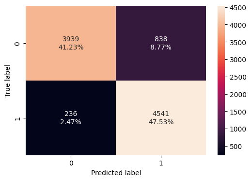

```python
#Calculating the confusion matrix
make_confusion_matrix(y_train_smote, y_train_pred)
```

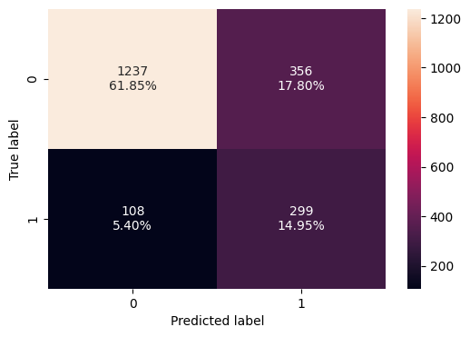

```python
#Calculating the confusion matrix
make_confusion_matrix(y_val, y_val_pred)  ## Complete the code to check the model's performance on the validation set
```

## Model Performance Comparison and Final Model Selection

```python
print("Model performances comparision")
metrics_df
```

```
Model performances comparision
```

[output not shown]

### Model comparision:

```python
# Use of best model to predict on TEST Data
y_test_pred = model_5.predict(X_test)
y_test_pred = (y_test_pred > 0.5)
print(y_test_pred)
```

[output not shown]

```python
#lets print classification report for test data
cr=classification_report(y_test,y_test_pred)
print(cr)
```

```
              precision    recall  f1-score   support

           0       0.92      0.76      0.83      1593
           1       0.44      0.74      0.55       407

    accuracy                           0.75      2000
   macro avg       0.68      0.75      0.69      2000
weighted avg       0.82      0.75      0.77      2000
```

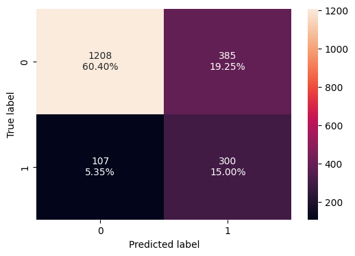

```python
#Calculating the confusion matrix
make_confusion_matrix(y_test,y_test_pred)
```

## Actionable Insights and Business Recommendations

### Actionable Insights:

The followings are major insights drawn from the analysis of the given data.

#### Customer Segmentation by Age:

The dataset reveals two prominent age groups: younger adults (late 20s to early 30s) and middle-aged individuals (around 40 years old). This segmentation suggests the need for tailored marketing strategies targeting each group’s specific needs and preferences.

#### High Churn in Older Customers:

There is a statistically significant positive correlation between age and churn, with older customers more likely to leave. This indicates a need to create retention strategies specifically aimed at older customers, possibly through loyalty programs or age-appropriate products/services.

#### Account Balance as a Churn Indicator:

Customers with higher account balances are more likely to churn. These customers might require more personalized engagement or value-added services to prevent churn.

#### Product Ownership and Churn Risk:

Customers with more products (2) show a significantly lower churn rate, cross-selling additional products can be an effective retention strategy. However, there is an anomaly where customers with 3 or 4 products have extremely high churn rates. This suggests the need to investigate further, potentially revisiting the value proposition of these products or understanding the specific needs of these customers.

#### Geographic Insights:

Germany has the highest rate of customer churn among the three countries (France, Germany, Spain). This indicates the need for a targeted retention strategy in Germany, potentially exploring local market conditions.

#### Active Membership as a Key Retention Factor:

Active members are significantly less likely to churn compared to inactive members. This highlights the importance of encouraging active engagement with the company's services such as regular check-ins, loyalty rewards, or personalized offers to inactive members.

#### Credit Card Ownership Not a Churn Predictor:

There is no significant difference in churn rates between customers with or without credit cards. This indicates that ownership of credit card should not be a focus for churn prediction or prevention.

#### Gender-Based Churn Patterns:

Females are more likely to churn compared to males. This suggests a potential need for gender-specific retention strategies.

### Business Recommendations:

#### Develop Age-Specific Engagement Programs:

Create targeted marketing campaigns and product offerings that cater to the two identified age groups.

#### Retention Strategies for High-Balance Customers:

Implement personalized financial planning services, loyalty rewards, or exclusive offers for customers with higher account balances to reduce their likelihood of churn.

#### Enhance Cross-Selling Efforts:

Actively promote the benefits of holding multiple products, particularly focusing on customers who currently own only one product.

#### Focus on Germany for Retention:

Investigate the specific reasons behind the high churn rate in Germany and tailor retention strategies to address these issues. Consider localizing offers, improving customer support, or enhancing the user experience in this region.

#### Increase Customer Engagement:

Develop initiatives to boost active membership.

#### Address Gender-Based Churn:

Conduct further analysis to understand why female customers are more likely to churn and develop targeted retention strategies that address their specific concerns.

#### Monitor Tenure Milestones:

Implement a proactive customer engagement program that targets customers approaching the 10-year tenure mark.

#### Focus on Recall in Churn Prediction Models:

Prioritize models with high recall in churn prediction to ensure that the majority of potential churners are identified, thereby allowing for timely intervention and retention efforts.

```python
!jupyter nbconvert --to html '/content/drive/MyDrive/MLProject_4/Project_4_Bank_Churner_Full_code.ipynb'
```

```
[NbConvertApp] Converting notebook /content/drive/MyDrive/MLProject_4/Project_4_Bank_Churner_Full_code.ipynb to html
[NbConvertApp] Writing 3143178 bytes to /content/drive/MyDrive/MLProject_4/Project_4_Bank_Churner_Full_code.html
```